# Tarea 1

Francisco Acosta 183270

```r
library(rio)
library(MASS)
library(tidyverse)
library(mvtnorm)
library(Matrix)
```

**Consideren los datos de tipo de cambio USD de la sesión 06 (`est46114 s06 data.csv`).**

```r
cambio <- import('est46114_s06_data.xls')
cambio <- as_tibble(cambio)
cambio <- cambio %>% dplyr::select(-Nicaragua)
cambio
```

```
## # A tibble: 492 x 80
##    Date                Canada Mexico Guatemala `El Salvador` Honduras
##    <dttm>               <dbl>  <dbl>     <dbl>         <dbl>    <dbl>
##  1 1970-01-01 00:00:00   1.11   9.38      7.53          20.2     14.4
##  2 1970-02-01 00:00:00   1.11   9.42      7.61          20.1     14.5
##  3 1970-03-01 00:00:00   1.11   9.45      7.78          20.2     14.5
##  4 1970-04-01 00:00:00   1.11   9.50      7.84          20.4     14.5
##  5 1970-05-01 00:00:00   1.12   9.51      7.74          20.5     14.5
##  6 1970-06-01 00:00:00   1.08   9.51      7.43          20.2     14.5
##  7 1970-07-01 00:00:00   1.08   9.50      7.59          20.0     14.6
##  8 1970-08-01 00:00:00   1.07   9.46      7.75          20.5     14.2
##  9 1970-09-01 00:00:00   1.07   9.49      7.76          20.5     14.7
## 10 1970-10-01 00:00:00   1.08   9.53      7.95          21.3     14.9
## # … with 482 more rows, and 74 more variables: `Costa Rica` <dbl>,
## #   Panama <dbl>, Jamaica <dbl>, `Dominican Rep` <dbl>,
## #   `Trin/Tobago` <dbl>, Colombia <dbl>, Venezuela <dbl>, Ecuador <dbl>,
## #   Peru <dbl>, Chile <dbl>, Brazil <dbl>, Paraguay <dbl>, Uruguay <dbl>,
## #   Argentina <dbl>, EU12 <dbl>, Sweden <dbl>, Norway <dbl>,
## #   Finland <dbl>, Denmark <dbl>, U.K. <dbl>, Ireland <dbl>,
## #   Luxembourg <dbl>, Netherlands <dbl>, France <dbl>, Germany <dbl>,
## #   Austria <dbl>, `Czech Rep` <dbl>, Hungary <dbl>, Switzerland <dbl>,
## #   Poland <dbl>, Russia <dbl>, Spain <dbl>, Portugal <dbl>, Italy <dbl>,
## #   Greece <dbl>, Turkey <dbl>, Syria <dbl>, Israel <dbl>, Jordan <dbl>,
## #   Kuwait <dbl>, `Saudi Arabia` <dbl>, India <dbl>, Pakistan <dbl>,
## #   Bangladesh <dbl>, `Sri Lanka` <dbl>, Thailand <dbl>, Malaysia <dbl>,
## #   Singapore <dbl>, Indonesia <dbl>, Philippines <dbl>, `China,PR` <dbl>,
## #   Korea <dbl>, `Hong Kong` <dbl>, Taiwan <dbl>, Japan <dbl>,
## #   Australia <dbl>, `New Zealand` <dbl>, Morocco <dbl>, Algeria <dbl>,
## #   Tunisia <dbl>, Egypt <dbl>, Cameroon <dbl>, Senegal <dbl>, `Sierra
## #   Leone` <dbl>, `Cote d'Ivoire` <dbl>, Ghana <dbl>, Nigeria <dbl>,
## #   Benin <dbl>, Congo <dbl>, Kenya <dbl>, Tanzania <dbl>,
## #   Mozambique <dbl>, `South Africa` <dbl>, Zambia <dbl>
```

**1. Implementen el procedimiento inferencial PCA considerando distribuciones iniciales no informativas para ($\mu, \Lambda$).**

```
## Importance of components:
##                           PC1     PC2     PC3     PC4     PC5    PC6
## Standard deviation     4.3666 1.89192 1.75867 1.50496 1.41041 1.3273
## Proportion of Variance 0.2414 0.04531 0.03915 0.02867 0.02518 0.0223
## Cumulative Proportion  0.2414 0.28666 0.32581 0.35448 0.37966 0.4020
##                            PC7     PC8     PC9    PC10    PC11    PC12
## Standard deviation     1.29467 1.24358 1.22156 1.19635 1.17756 1.15851
## Proportion of Variance 0.02122 0.01958 0.01889 0.01812 0.01755 0.01699
## Cumulative Proportion  0.42318 0.44276 0.46164 0.47976 0.49731 0.51430
##                           PC13    PC14   PC15    PC16    PC17    PC18
## Standard deviation     1.13976 1.12533 1.1136 1.10271 1.08578 1.07451
## Proportion of Variance 0.01644 0.01603 0.0157 0.01539 0.01492 0.01461
## Cumulative Proportion  0.53075 0.54678 0.5625 0.57787 0.59279 0.60740
##                           PC19    PC20   PC21    PC22    PC23    PC24
## Standard deviation     1.06097 1.04641 1.0327 1.02414 1.01037 0.98734
## Proportion of Variance 0.01425 0.01386 0.0135 0.01328 0.01292 0.01234
## Cumulative Proportion  0.62165 0.63551 0.6490 0.66229 0.67521 0.68755
##                           PC25    PC26    PC27    PC28    PC29    PC30
## Standard deviation     0.98267 0.97298 0.96414 0.95884 0.95012 0.93826
## Proportion of Variance 0.01222 0.01198 0.01177 0.01164 0.01143 0.01114
## Cumulative Proportion  0.69977 0.71176 0.72352 0.73516 0.74659 0.75773
##                           PC31    PC32    PC33    PC34    PC35    PC36
## Standard deviation     0.92589 0.92154 0.91450 0.89036 0.86550 0.86083
## Proportion of Variance 0.01085 0.01075 0.01059 0.01003 0.00948 0.00938
## Cumulative Proportion  0.76858 0.77933 0.78992 0.79995 0.80944 0.81882
##                           PC37    PC38    PC39    PC40    PC41    PC42
## Standard deviation     0.85294 0.84844 0.83529 0.82849 0.81393 0.78456
## Proportion of Variance 0.00921 0.00911 0.00883 0.00869 0.00839 0.00779
## Cumulative Proportion  0.82803 0.83714 0.84597 0.85466 0.86304 0.87084
##                           PC43    PC44   PC45    PC46    PC47   PC48
## Standard deviation     0.78357 0.77659 0.7647 0.75119 0.74121 0.7166
## Proportion of Variance 0.00777 0.00763 0.0074 0.00714 0.00695 0.0065
## Cumulative Proportion  0.87861 0.88624 0.8936 0.90079 0.90774 0.9142
##                           PC49    PC50    PC51    PC52    PC53    PC54
## Standard deviation     0.71278 0.69014 0.68203 0.67014 0.64507 0.62610
## Proportion of Variance 0.00643 0.00603 0.00589 0.00568 0.00527 0.00496
## Cumulative Proportion  0.92067 0.92670 0.93259 0.93827 0.94354 0.94850
##                           PC55    PC56    PC57    PC58   PC59    PC60
## Standard deviation     0.61333 0.59582 0.55975 0.54212 0.5260 0.50694
## Proportion of Variance 0.00476 0.00449 0.00397 0.00372 0.0035 0.00325
## Cumulative Proportion  0.95326 0.95776 0.96172 0.96544 0.9689 0.97220
##                           PC61   PC62    PC63    PC64    PC65    PC66
## Standard deviation     0.48941 0.4783 0.44610 0.42859 0.41412 0.40246
## Proportion of Variance 0.00303 0.0029 0.00252 0.00233 0.00217 0.00205
## Cumulative Proportion  0.97523 0.9781 0.98065 0.98297 0.98514 0.98719
##                           PC67    PC68    PC69    PC70    PC71   PC72
## Standard deviation     0.39442 0.37468 0.34745 0.31339 0.30426 0.2942
## Proportion of Variance 0.00197 0.00178 0.00153 0.00124 0.00117 0.0011
## Cumulative Proportion  0.98916 0.99094 0.99247 0.99371 0.99488 0.9960
##                           PC73    PC74    PC75    PC76    PC77    PC78
## Standard deviation     0.27536 0.25334 0.22773 0.20343 0.20204 0.17074
## Proportion of Variance 0.00096 0.00081 0.00066 0.00052 0.00052 0.00037
## Cumulative Proportion  0.99694 0.99775 0.99841 0.99893 0.99945 0.99982
##                           PC79
## Standard deviation     0.12066
## Proportion of Variance 0.00018
## Cumulative Proportion  1.00000
```

Examinemos los 5 primeros componentes. En total, capturan 37.96% de la variabilidad. No es mucho.

```
##                 PC1   PC2   PC3   PC4   PC5   PC6   PC7   PC8   PC9  PC10
## Canada        -0.07  0.17 -0.03  0.22  0.18 -0.15  0.11 -0.03  0.12 -0.02
## Mexico         0.02  0.06 -0.03  0.08  0.12 -0.16  0.09  0.03  0.12 -0.14
## Guatemala     -0.01  0.04 -0.02 -0.16  0.18 -0.07 -0.11  0.15  0.25 -0.11
## El Salvador    0.02  0.01 -0.02  0.00 -0.08 -0.16 -0.09 -0.34 -0.06  0.10
## Honduras       0.00  0.02  0.00 -0.16 -0.05 -0.13  0.03  0.03  0.37  0.03
## Costa Rica     0.01  0.00 -0.03 -0.05  0.02  0.00 -0.08  0.04 -0.14  0.25
## Panama        -0.01 -0.02 -0.01 -0.33  0.14 -0.04  0.01 -0.04 -0.01 -0.06
## Jamaica       -0.02 -0.01 -0.01 -0.05  0.02 -0.09  0.07  0.17 -0.21 -0.10
## Dominican Rep -0.01 -0.01  0.01 -0.02 -0.04 -0.01  0.03  0.27  0.04 -0.27
## Trin/Tobago   -0.01  0.00 -0.04 -0.13  0.10 -0.16 -0.11 -0.40  0.04 -0.11
## Colombia      -0.02  0.18 -0.12  0.04  0.32 -0.18  0.01  0.06 -0.06  0.06
## Venezuela     -0.01  0.05  0.03  0.07  0.19  0.44  0.22 -0.24  0.18 -0.05
## Ecuador        0.01  0.00 -0.05 -0.02  0.10 -0.17 -0.07 -0.18 -0.14 -0.05
## Peru          -0.02 -0.01  0.05  0.02 -0.06 -0.05 -0.11  0.05  0.04 -0.12
## Chile         -0.04  0.11 -0.07  0.10  0.19 -0.01  0.19  0.04 -0.07  0.08
## Brazil        -0.01  0.10 -0.07  0.16  0.20  0.02  0.03  0.02 -0.26  0.05
## Paraguay      -0.01  0.09 -0.04  0.05  0.25  0.47  0.18 -0.21  0.14 -0.04
## Uruguay        0.01  0.04  0.00  0.03  0.09 -0.04  0.20  0.07 -0.09 -0.09
## Argentina      0.01  0.02 -0.01  0.11  0.15  0.15 -0.37  0.04 -0.15 -0.13
## EU12          -0.21  0.00  0.08  0.01 -0.03 -0.01  0.00 -0.02  0.02  0.03
## Sweden        -0.19  0.10  0.08  0.07  0.01 -0.01 -0.01  0.01  0.01  0.05
## Norway        -0.20  0.03  0.06  0.03 -0.02 -0.02  0.02  0.02  0.03  0.01
## Finland       -0.20  0.03  0.08  0.02 -0.04 -0.02 -0.01 -0.02  0.01  0.01
## Denmark       -0.22  0.00  0.08 -0.01 -0.05 -0.01  0.00 -0.03  0.01  0.01
## U.K.          -0.16  0.03  0.07  0.00  0.01 -0.08  0.03  0.01  0.08 -0.17
## Ireland       -0.20  0.01  0.09  0.00 -0.06 -0.03 -0.02 -0.02  0.04 -0.06
## Luxembourg    -0.22  0.00  0.08 -0.02 -0.04  0.00 -0.01 -0.02  0.01  0.00
## Netherlands   -0.22 -0.01  0.08 -0.01 -0.06  0.01  0.00 -0.02  0.01  0.00
## France        -0.22 -0.01  0.08  0.01 -0.04  0.00 -0.02 -0.03  0.00  0.03
## Germany       -0.22  0.00  0.08 -0.02 -0.04  0.00  0.00 -0.03  0.01  0.00
## Austria       -0.21 -0.01  0.08 -0.02 -0.04  0.00 -0.01 -0.03  0.00 -0.02
## Czech Rep     -0.13  0.07  0.00  0.09  0.01 -0.04 -0.01 -0.01 -0.06  0.19
## Hungary       -0.08  0.10  0.06  0.14  0.17  0.12 -0.23 -0.02 -0.16 -0.25
## Switzerland   -0.07  0.03  0.06  0.08 -0.03  0.09 -0.17  0.07 -0.17 -0.33
## Poland        -0.01  0.03  0.00  0.09  0.16  0.16 -0.38  0.10 -0.02 -0.05
## Russia         0.01  0.02 -0.03 -0.08  0.10 -0.03 -0.03 -0.03 -0.11 -0.03
## Spain         -0.19  0.01  0.09  0.04 -0.03  0.02 -0.02  0.04  0.04  0.05
## Portugal      -0.20  0.01  0.08 -0.03 -0.03 -0.01 -0.04 -0.01 -0.01  0.05
## Italy         -0.20  0.01  0.09  0.03 -0.03 -0.02 -0.01 -0.01  0.03  0.04
```

[output cut: 25 more lines]

```
## Tunisia       -0.20  0.01  0.07  0.00  0.00  0.01 -0.03  0.00  0.01 -0.02
## Egypt          0.00  0.00 -0.01 -0.08 -0.03  0.02  0.25  0.09 -0.32 -0.01
## Cameroon      -0.15 -0.26 -0.25  0.06  0.05 -0.01 -0.01  0.02  0.01  0.03
## Senegal       -0.15 -0.26 -0.24  0.08  0.03  0.02  0.01  0.00 -0.01  0.04
## Sierra Leone   0.01 -0.04  0.02  0.02  0.03 -0.20 -0.09 -0.10 -0.12 -0.15
## Cote d'Ivoire -0.15 -0.26 -0.24  0.08  0.05 -0.04  0.00 -0.01  0.00  0.02
## Ghana          0.00  0.02 -0.04  0.06  0.06 -0.17 -0.21 -0.23  0.02  0.02
## Nigeria       -0.01  0.00 -0.02 -0.04  0.00 -0.08  0.02  0.09 -0.20 -0.23
## Benin         -0.16 -0.25 -0.22  0.08  0.06 -0.02  0.01  0.03  0.00  0.04
## Congo         -0.15 -0.27 -0.18  0.01 -0.01  0.03  0.00 -0.05 -0.01 -0.02
## Kenya         -0.05  0.03  0.09 -0.10  0.11 -0.07 -0.07 -0.06  0.02  0.18
## Tanzania      -0.01  0.00 -0.04 -0.13  0.22  0.10 -0.29  0.28  0.16  0.19
## Mozambique    -0.02  0.09  0.06 -0.14  0.12 -0.02 -0.08  0.14 -0.17  0.26
## South Africa  -0.08  0.12  0.00  0.11  0.12 -0.07  0.07  0.30  0.15 -0.11
## Zambia         0.00 -0.02 -0.04  0.02 -0.04  0.06  0.13  0.10  0.09  0.03
```

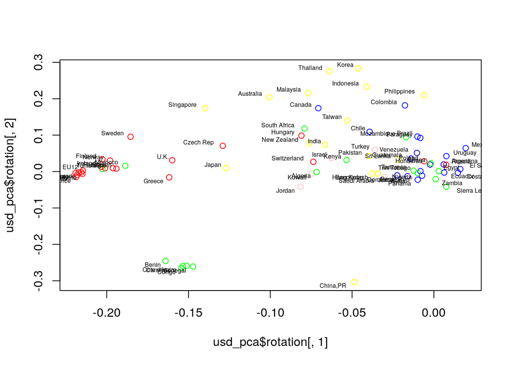

```r
# hagamos colores para distinguir continentes
colores <- c(rep('blue',19,), rep('red', 21), rep('pink', 6),
             rep('yellow',16), rep('green', 17))
plot(x=usd_pca$rotation[,1],
     y = usd_pca$rotation[,2],
     col=colores)
calibrate::textxy(X=usd_pca$rotation[,1],
                  Y = usd_pca$rotation[,2],
                  labs=rownames(usd_pca$rotation))
```

**2. Reporten que economia tiene el mayor peso esperado en la descomposicion PCA.**

```r
as_tibble(pc_rotados) %>%
    mutate(pais=rownames(pc_rotados)) %>%
    dplyr::select(pais, PC1, PC2) %>%
    arrange(desc(PC1))
```

```
## # A tibble: 79 x 3
##    pais           PC1   PC2
##    <chr>        <dbl> <dbl>
##  1 Mexico        0.02  0.06
##  2 El Salvador   0.02  0.01
##  3 Costa Rica    0.01  0
##  4 Ecuador       0.01  0
##  5 Uruguay       0.01  0.04
##  6 Argentina     0.01  0.02
##  7 Russia        0.01  0.02
##  8 Sierra Leone  0.01 -0.04
##  9 Honduras      0     0.02
## 10 Egypt         0     0
## # … with 69 more rows
```

Los países con mayor peso son países para la dimensión 1 son países de América en la parte positiva (incluyendo a México, El Salvador y Costa Rica) y países europeos en la parte negativa. En general, esto es similar a lo que observamos en la gráfica.

**3. Reporten que economia tiene la mayor consistencia en estimacion de los $c_js$ correspondientes.**

```r
a0 <- 1
s0 <- 1
m0 <- matrix(0,ncol=1,nrow=79)
B0 <- diag(1,ncol=79,nrow=79)

gaussian.posterior <- function(data,m0,s0,a0,B0){
  xbar <- as.matrix(colMeans(usd))
  S <- cov(usd)
  n <- nrow(usd)
  p <- ncol(usd)
  # Posterior hiperparameters
  sn <- s0 + n
  an <- a0 + n/2
  mn <- (s0*m0 + n*xbar)/sn
  Bn <- B0 + (n/2)*(S + (s0/sn)*(xbar-m0)%*%t(xbar-m0))
  # Output
  output <- list(mn,sn,an,Bn)
  return(output)
}

output <- gaussian.posterior(data,m0,s0,a0,B0)
```

```r
M <- 1000
mu.sim <- matrix(NA,nrow=M, ncol=ncol(usd))
Lambda.sim <- array(NA,dim=c(M,ncol(usd),ncol(usd)))
e.sim <- matrix(NA,nrow=M, ncol=ncol(usd))
V.sim <- array(NA,dim=c(M,ncol(usd),ncol(usd)))
C.sim <- array(NA,dim=c(M,nrow(usd),ncol(usd)))
X <- as.matrix(usd)
for(m in 1:M){
  # Simulacion (mu,Lambda)
  Lambda.sim[m,,] <- rWishart(1, output[[3]], output[[4]])
  mu.sim[m,] <- mvrnorm(1, mu=output[[1]], Sigma=solve(output[[2]]*Lambda.sim[m,,]), tol = 1e-6)
  # Simulacion (e,V) + C
  eigen_aux <- eigen(solve(Lambda.sim[m,,]))
  e.sim[m,] <- eigen_aux$values
  V.sim[m,,] <- eigen_aux$vectors
  C.sim[m,,] <- X %*% V.sim[m,,]
}
```

Ahora sí, observemos la consistencia de la primera economía, Canadá. Para medir esto podeos medir la desviacion estándar

```r
cp1 <- c()
for (n in 1:dim(C.sim)[3]) {
    cp1 <- c(cp1, sd(C.sim[,1,n]))
}
cp2 <- c()
for (n in 1:dim(C.sim)[3]) {
    cp2 <- c(cp2, sd(C.sim[,2,n]))
}

a <- tibble(pais = colnames(usd),
       consistencia_pc1 = cp1,
       consistencia_pc2 = cp2)

a %>% arrange((consistencia_pc1))
```

```
## # A tibble: 79 x 3
##    pais          consistencia_pc1 consistencia_pc2
##    <chr>                    <dbl>            <dbl>
##  1 Panama                  0.0167           0.0643
##  2 El Salvador             0.0169           0.0678
##  3 Canada                  0.0170           0.0674
##  4 Mexico                  0.0170           0.0674
##  5 Colombia                0.0173           0.0681
##  6 Chile                   0.0173           0.0675
##  7 Honduras                0.0174           0.0658
##  8 Uruguay                 0.0175           0.0709
##  9 Argentina               0.0176           0.0696
## 10 Dominican Rep           0.0177           0.0680
## # … with 69 more rows
```

```r
a %>% arrange((consistencia_pc2))
```

```
## # A tibble: 79 x 3
##    pais          consistencia_pc1 consistencia_pc2
##    <chr>                    <dbl>            <dbl>
##  1 Panama                  0.0167           0.0643
##  2 Honduras                0.0174           0.0658
##  3 Peru                    0.0185           0.0667
##  4 Costa Rica              0.0183           0.0670
##  5 Guatemala               0.0179           0.0672
##  6 Mexico                  0.0170           0.0674
##  7 Canada                  0.0170           0.0674
##  8 Chile                   0.0173           0.0675
##  9 El Salvador             0.0169           0.0678
## 10 Dominican Rep           0.0177           0.0680
## # … with 69 more rows
```